# Housing Price

Asad Aslam - University of Catania

# **Housing Data set**

```r
housing_data = read.csv(file='Housing.csv')
```

**Problem Statement**

Consider a real estate company data set containing the prices of properties. Essentially, I wants to identify the following things:

1. In my opinion, the price increased when the area of house increase.
2. Other variables affecting the prices of house? eg. bedrooms, bathrooms, etc.
3. To create a linear model that quantitatively relates house prices with variables.

**Libraries**

```r
library(ggplot2)
library(ggcorrplot)
library(corrplot)
library(pacman)
pacman::p_load(pacman, dplyr, ggplot2, rio, gridExtra, scales, ggcorrplot, caret)
```

## **Feature Analysis**

```r
dim(housing_data)
```

```
## [1] 545  13
```

The housing data set contains 545 rows and 13 columns. Further details are mentioned below:

**Column Names**

```r
colnames(housing_data)
```

```
##  [1] "price"            "area"             "bedrooms"         "bathrooms"
##  [5] "furnishingstatus" "stories"          "mainroad"         "guestroom"
##  [9] "basement"         "hotwaterheating"  "airconditioning"  "parking"
## [13] "prefarea"
```

**Column Details**

1. Price = The price of house in Indian Rupees.
2. Area = The total number of area covered by house in square feet.
3. Bedrooms = The total number of bedrooms in a house.
4. Bathrooms = The total number of bathrooms in a house.
5. Furnishing Status = It contains the status | “1” : Furnished House, “0”: Unfurnished House, “0.5”: Semi-Furnished House
6. Stories = The total number of stories in a house.
7. Main Road = Has main road facing or not | Has: 1, Not: 0
8. Guestroom = Has guestroom or not | Has: 1, Not: 0
9. Basement = Has basement or not | Has: 1, Not: 0
10. Hot water heating = Has Hot water heating or not | Has: 1, Not: 0
11. Air conditioning = Has Air conditioning or not | Has: 1, Not: 0
12. Parking = The total number of car parking available in a house.
13. Prefarea = Has Prefarea or not | Has: 1, Not: 0

**Structure** This helps in understanding the structure of the data set, data type of each attribute. In this data there are some continuous variable and some categorical variables.

```r
str(housing_data)
```

```
## 'data.frame':    545 obs. of  13 variables:
##  $ price           : int  13300000 12250000 12250000 12215000 11410000 10850000 10150000 10150000 9870000 9800000 ...
##  $ area            : int  7420 8960 9960 7500 7420 7500 8580 16200 8100 5750 ...
##  $ bedrooms        : int  4 4 3 4 4 3 4 5 4 3 ...
##  $ bathrooms       : int  2 4 2 2 1 3 3 3 1 2 ...
##  $ furnishingstatus: num  1 1 0.5 1 1 0.5 0.5 0 1 0 ...
##  $ stories         : int  3 4 2 2 2 1 4 2 2 4 ...
##  $ mainroad        : int  1 1 1 1 1 1 1 1 1 1 ...
##  $ guestroom       : int  0 0 0 0 1 0 0 0 1 1 ...
##  $ basement        : int  0 0 1 1 1 1 0 0 1 0 ...
##  $ hotwaterheating : int  0 0 0 0 0 0 0 0 0 0 ...
##  $ airconditioning : int  1 1 0 1 1 1 1 0 1 1 ...
##  $ parking         : int  2 3 2 3 2 2 2 0 2 1 ...
##  $ prefarea        : int  1 0 1 1 0 1 1 0 1 1 ...
```

**Data Head**

```r
head(housing_data)
```

```
##      price area bedrooms bathrooms furnishingstatus stories mainroad guestroom
## 1 13300000 7420        4         2              1.0       3        1         0
## 2 12250000 8960        4         4              1.0       4        1         0
## 3 12250000 9960        3         2              0.5       2        1         0
## 4 12215000 7500        4         2              1.0       2        1         0
## 5 11410000 7420        4         1              1.0       2        1         1
## 6 10850000 7500        3         3              0.5       1        1         0
##   basement hotwaterheating airconditioning parking prefarea
## 1        0               0               1       2        1
## 2        0               0               1       3        0
## 3        1               0               0       2        1
## 4        1               0               1       3        1
## 5        1               0               1       2        0
## 6        1               0               1       2        1
```

**Summary**

```r
summary(housing_data)
```

```
##      price               area          bedrooms       bathrooms
##  Min.   : 1750000   Min.   : 1650   Min.   :1.000   Min.   :1.000
##  1st Qu.: 3430000   1st Qu.: 3600   1st Qu.:2.000   1st Qu.:1.000
##  Median : 4340000   Median : 4600   Median :3.000   Median :1.000
##  Mean   : 4766729   Mean   : 5151   Mean   :2.965   Mean   :1.286
##  3rd Qu.: 5740000   3rd Qu.: 6360   3rd Qu.:3.000   3rd Qu.:2.000
##  Max.   :13300000   Max.   :16200   Max.   :6.000   Max.   :4.000
##  furnishingstatus    stories         mainroad        guestroom
##  Min.   :0.0000   Min.   :1.000   Min.   :0.0000   Min.   :0.000
##  1st Qu.:0.0000   1st Qu.:1.000   1st Qu.:1.0000   1st Qu.:0.000
##  Median :0.5000   Median :2.000   Median :1.0000   Median :0.000
##  Mean   :0.4651   Mean   :1.806   Mean   :0.8587   Mean   :0.178
##  3rd Qu.:1.0000   3rd Qu.:2.000   3rd Qu.:1.0000   3rd Qu.:0.000
##  Max.   :1.0000   Max.   :4.000   Max.   :1.0000   Max.   :1.000
##     basement      hotwaterheating   airconditioning     parking
##  Min.   :0.0000   Min.   :0.00000   Min.   :0.0000   Min.   :0.0000
##  1st Qu.:0.0000   1st Qu.:0.00000   1st Qu.:0.0000   1st Qu.:0.0000
##  Median :0.0000   Median :0.00000   Median :0.0000   Median :0.0000
##  Mean   :0.3505   Mean   :0.04587   Mean   :0.3156   Mean   :0.6936
##  3rd Qu.:1.0000   3rd Qu.:0.00000   3rd Qu.:1.0000   3rd Qu.:1.0000
##  Max.   :1.0000   Max.   :1.00000   Max.   :1.0000   Max.   :3.0000
##     prefarea
##  Min.   :0.0000
##  1st Qu.:0.0000
##  Median :0.0000
##  Mean   :0.2349
##  3rd Qu.:0.0000
##  Max.   :1.0000
```

```r
orig_data = housing_data
housing_data$furnishingstatus <- factor(housing_data$furnishingstatus, levels = c(0,0.5,1),labels = c("unfurnished", "semi-furnished", "furnished"))
housing_data$bedrooms<-as.factor(housing_data$bedrooms)
housing_data$bathrooms<-as.factor(housing_data$bathrooms)
housing_data$guestroom<-as.factor(housing_data$guestroom)
housing_data$stories<-as.factor(housing_data$stories)
housing_data$basement<-as.factor(housing_data$basement)
housing_data$airconditioning<-as.factor(housing_data$airconditioning)
housing_data$parking<-as.factor(housing_data$parking)
housing_data$hotwaterheating<-as.factor(housing_data$hotwaterheating)
housing_data$mainroad<-as.factor(housing_data$mainroad)
```

```r
summary(housing_data$furnishingstatus)
```

```
##    unfurnished semi-furnished      furnished
##            178            227            140
```

```r
summary(housing_data$bedrooms)
```

```
##   1   2   3   4   5   6
##   2 136 300  95  10   2
```

```r
summary(housing_data$bathrooms)
```

```
##   1   2   3   4
## 401 133  10   1
```

```r
summary(housing_data$guestroom)
```

```
##   0   1
## 448  97
```

```r
summary(housing_data$stories)
```

```
##   1   2   3   4
## 227 238  39  41
```

```r
summary(housing_data$basement)
```

```
##   0   1
## 354 191
```

```r
summary(housing_data$airconditioning)
```

```
##   0   1
## 373 172
```

```r
summary(housing_data$parking)
```

```
##   0   1   2   3
## 299 126 108  12
```

```r
summary(housing_data$hotwaterheating)
```

```
##   0   1
## 520  25
```

```r
summary(housing_data$mainroad)
```

```
##   0   1
##  77 468
```

```r
summary(housing_data$price)
```

```
##     Min.  1st Qu.   Median     Mean  3rd Qu.     Max.
##  1750000  3430000  4340000  4766729  5740000 13300000
```

```r
summary(housing_data$area)
```

```
##    Min. 1st Qu.  Median    Mean 3rd Qu.    Max.
##    1650    3600    4600    5151    6360   16200
```

**Data Analysis through pie charts**

Lets visualize the data of different variables with respect to the percentage in pie charts

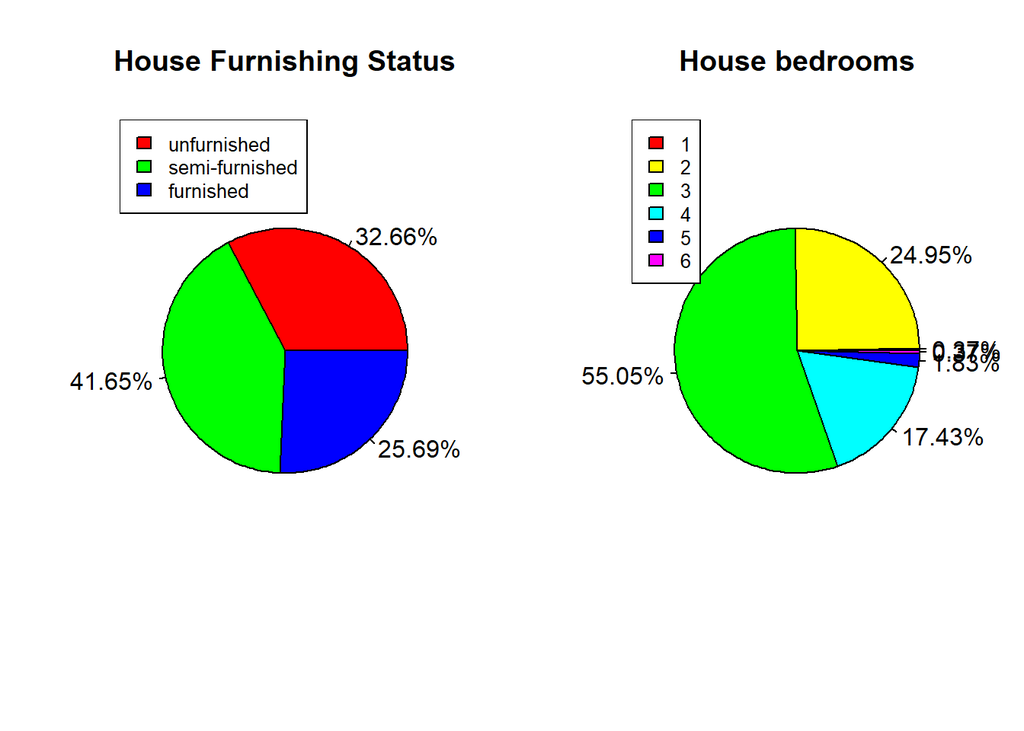

```r
pie_data = housing_data
par(mfrow=c(1,2))

#Price
pie(table(pie_data$furnishingstatus), labels =paste0( round((table(pie_data$furnishingstatus)/length(pie_data$furnishingstatus))*100,2) , "%") ,main = "House Furnishing Status",col = rainbow(length(table(pie_data$furnishingstatus))))
legend("topleft", names(table(pie_data$furnishingstatus)), cex = 0.8,
   fill = rainbow(length(table(pie_data$furnishingstatus))))

#Bedrooms
pie(table(pie_data$bedrooms), labels =paste0( round((table(pie_data$bedrooms)/length(pie_data$bedrooms))*100,2) , "%") ,main = "House bedrooms",col = rainbow(length(table(pie_data$bedrooms))))
legend("topleft", names(table(pie_data$bedrooms)), cex = 0.8,
   fill = rainbow(length(table(pie_data$bedrooms))))
```

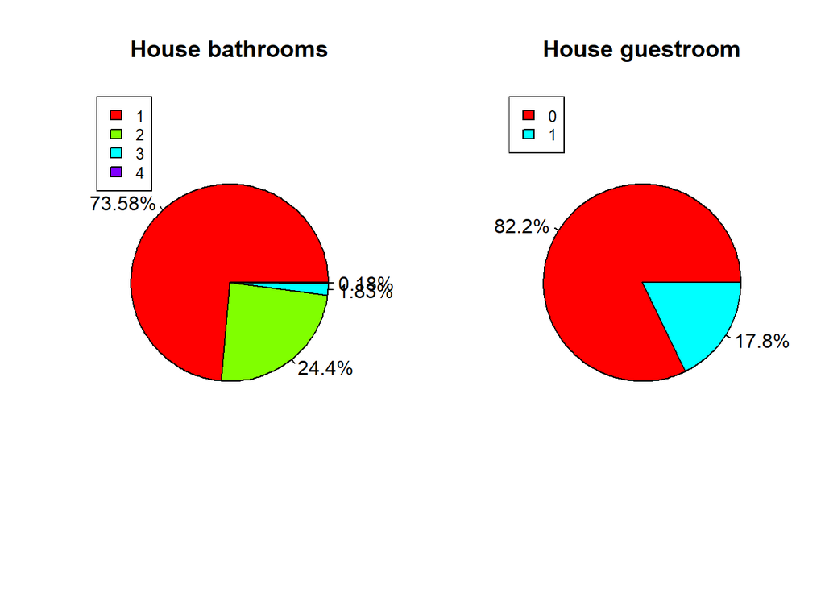

```r
#Bathrooms
pie(table(pie_data$bathrooms), labels =paste0( round((table(pie_data$bathrooms)/length(pie_data$bathrooms))*100,2) , "%") ,main = "House bathrooms",col = rainbow(length(table(pie_data$bathrooms))))
legend("topleft", names(table(pie_data$bathrooms)), cex = 0.8,
fill = rainbow(length(table(pie_data$bathrooms))))

#Guestrooms
pie(table(pie_data$guestroom), labels =paste0( round((table(pie_data$guestroom)/length(pie_data$guestroom))*100,2) , "%") ,main = "House guestroom",col = rainbow(length(table(pie_data$guestroom))))
legend("topleft", names(table(pie_data$guestroom)), cex = 0.8,
   fill = rainbow(length(table(pie_data$guestroom))))
```

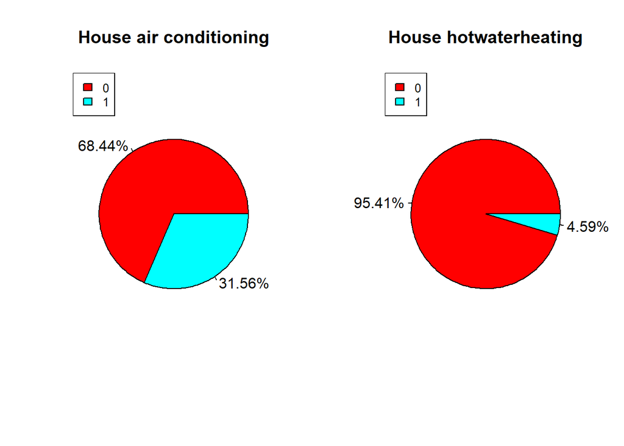

```r
#Airconditioning
pie(table(pie_data$airconditioning), labels =paste0( round((table(pie_data$airconditioning)/length(pie_data$airconditioning))*100,2) , "%") ,main = "House air conditioning",col = rainbow(length(table(pie_data$airconditioning))))
legend("topleft", names(table(pie_data$airconditioning)), cex = 0.8,
fill = rainbow(length(table(pie_data$airconditioning))))

#Hotwaterheating
pie(table(pie_data$hotwaterheating), labels =paste0( round((table(pie_data$hotwaterheating)/length(pie_data$hotwaterheating))*100,2) , "%") ,main = "House hotwaterheating",col = rainbow(length(table(pie_data$hotwaterheating))))
legend("topleft", names(table(pie_data$hotwaterheating)), cex = 0.8,
fill = rainbow(length(table(pie_data$hotwaterheating))))
```

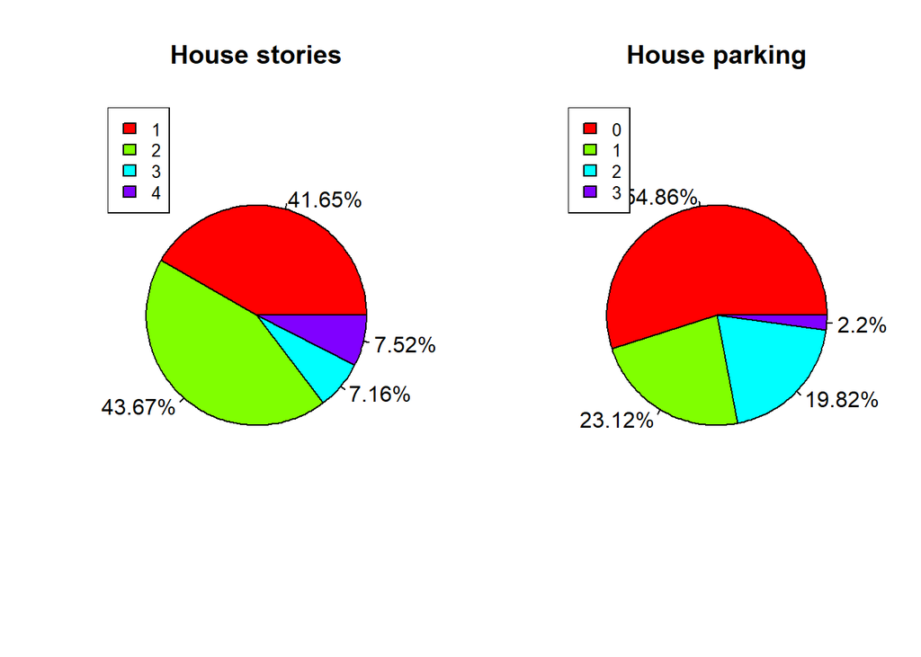

```r
#stories
pie(table(pie_data$stories), labels =paste0( round((table(pie_data$stories)/length(pie_data$stories))*100,2) , "%") ,main = "House stories",col = rainbow(length(table(pie_data$stories))))
legend("topleft", names(table(pie_data$stories)), cex = 0.8,
fill = rainbow(length(table(pie_data$stories))))

#parking
pie(table(pie_data$parking), labels =paste0( round((table(pie_data$parking)/length(pie_data$parking))*100,2) , "%") ,main = "House parking",col = rainbow(length(table(pie_data$parking))))
legend("topleft", names(table(pie_data$parking)), cex = 0.8,
fill = rainbow(length(table(pie_data$parking))))
```

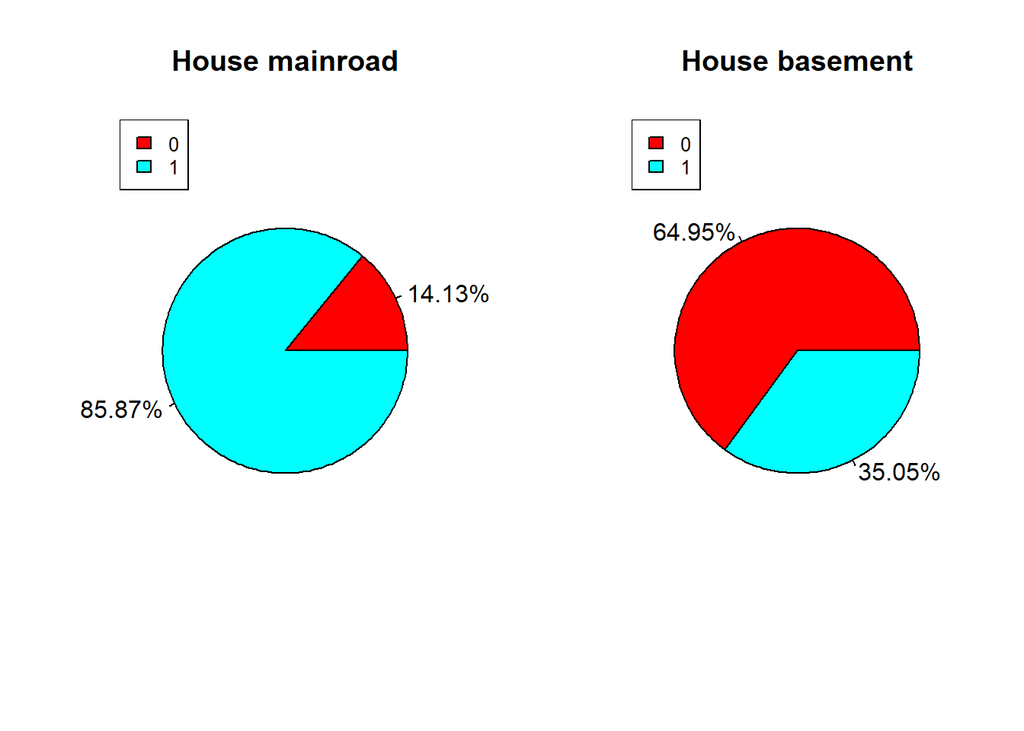

```r
#mainroad
pie(table(pie_data$mainroad), labels =paste0( round((table(pie_data$mainroad)/length(pie_data$mainroad))*100,2) , "%") ,main = "House mainroad",col = rainbow(length(table(pie_data$mainroad))))
legend("topleft", names(table(pie_data$mainroad)), cex = 0.8,
fill = rainbow(length(table(pie_data$mainroad))))

#basement
pie(table(pie_data$basement), labels =paste0( round((table(pie_data$basement)/length(pie_data$basement))*100,2) , "%") ,main = "House basement",col = rainbow(length(table(pie_data$basement))))
legend("topleft", names(table(pie_data$basement)), cex = 0.8,
fill = rainbow(length(table(pie_data$basement))))
```

**Data Analysis through bar graph**

Lets visualize the data of variables with respect to the count in bar graph

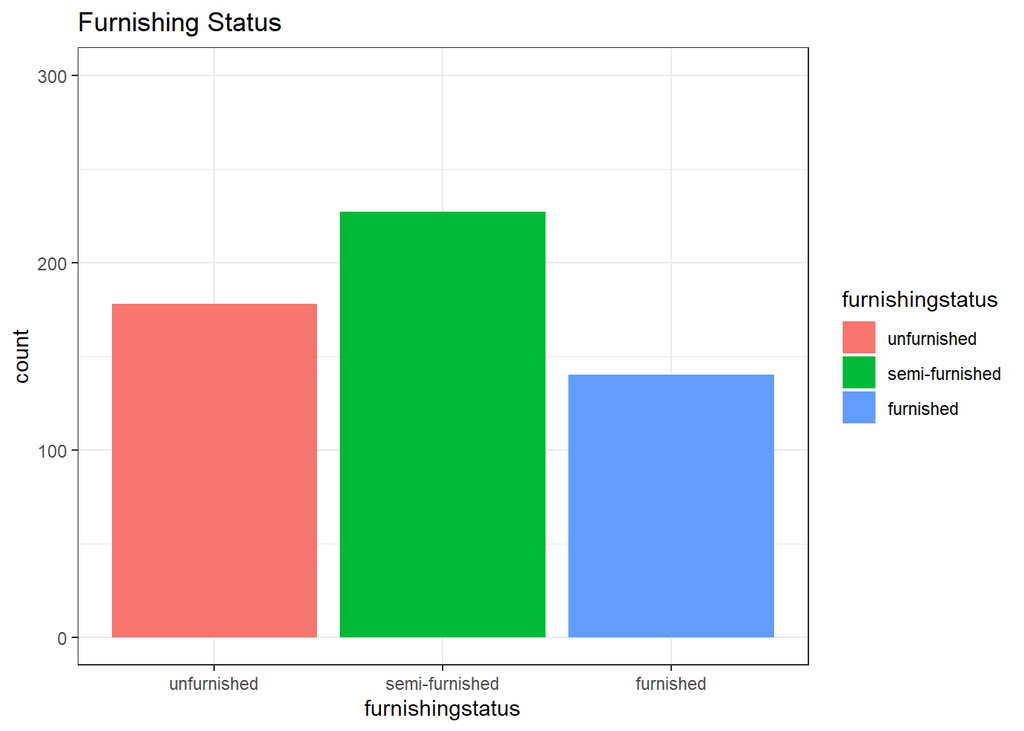

```r
p1 <-  ggplot(housing_data, aes(x=furnishingstatus, fill=furnishingstatus)) +
  theme_bw() +
  geom_bar() +
  ylim(0, 300) +
  labs(title = "Furnishing Status") +
  scale_x_discrete()
p1
```

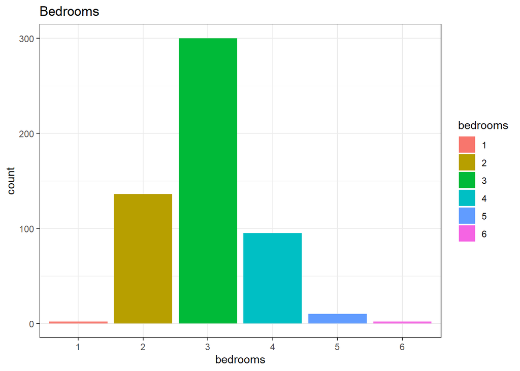

```r
p2 <-  ggplot(housing_data, aes(x=bedrooms, fill=bedrooms)) +
  theme_bw() +
  geom_bar() +
  ylim(0, 300) +
  labs(title = "Bedrooms") +
  scale_x_discrete()
p2
```

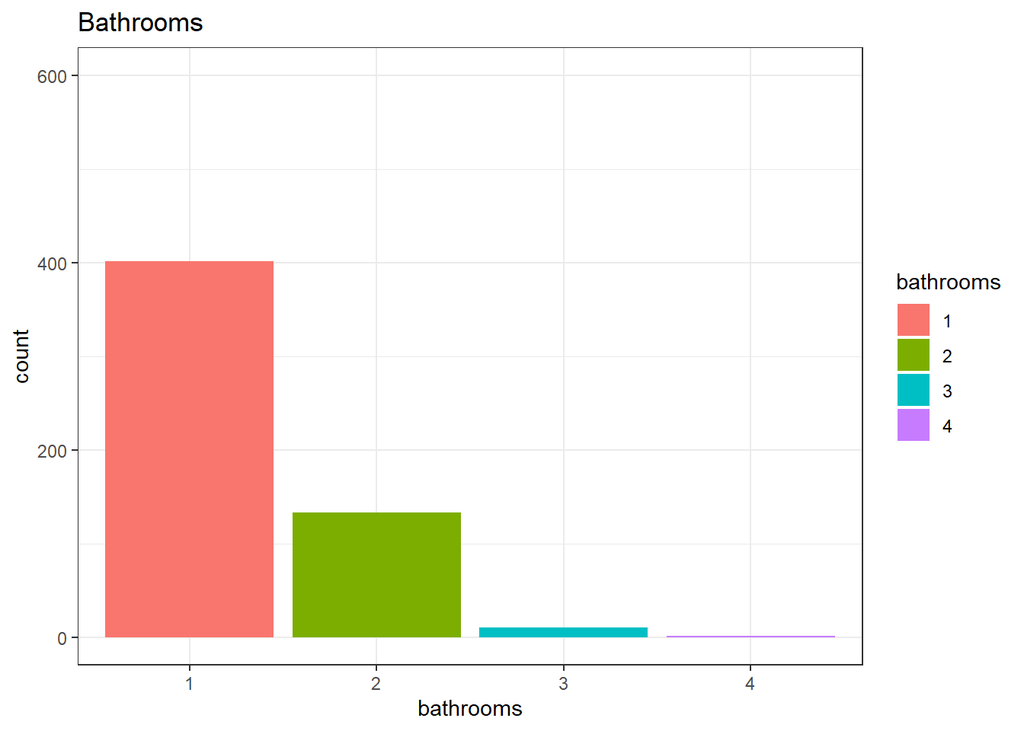

```r
p3 <-  ggplot(housing_data, aes(x=bathrooms, fill=bathrooms)) +
  theme_bw() +
  geom_bar() +
  ylim(0, 600) +
  labs(title = "Bathrooms") +
  scale_x_discrete()
p3
```

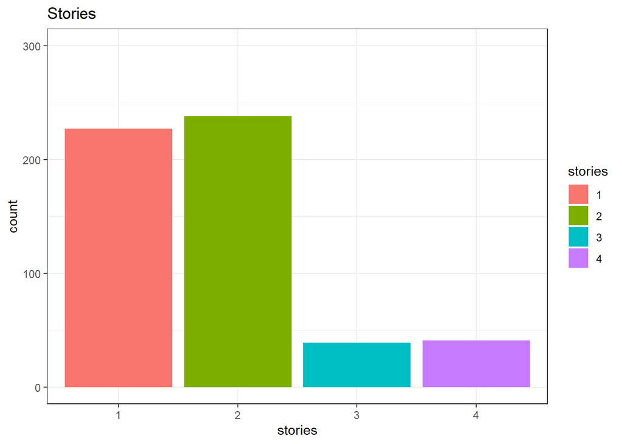

```r
p4 <-  ggplot(housing_data, aes(x=stories, fill=stories)) +
  theme_bw() +
  geom_bar() +
  ylim(0, 300) +
  labs(title = "Stories") +
  scale_x_discrete()
p4
```

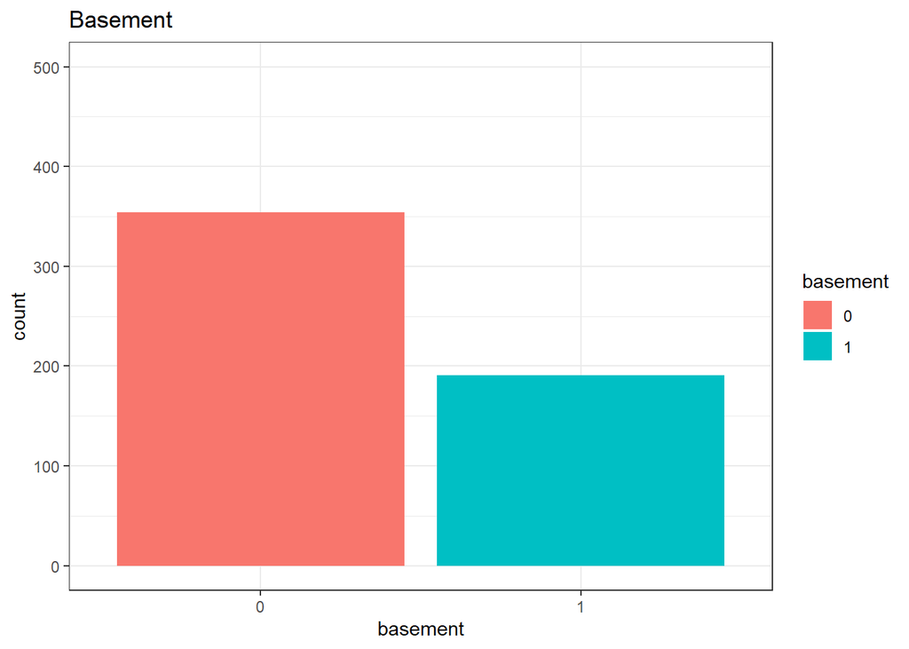

```r
p5 <-  ggplot(housing_data, aes(x=basement, fill=basement)) +
  theme_bw() +
  geom_bar() +
  ylim(0, 500) +
  labs(title = "Basement") +
  scale_x_discrete()
p5
```

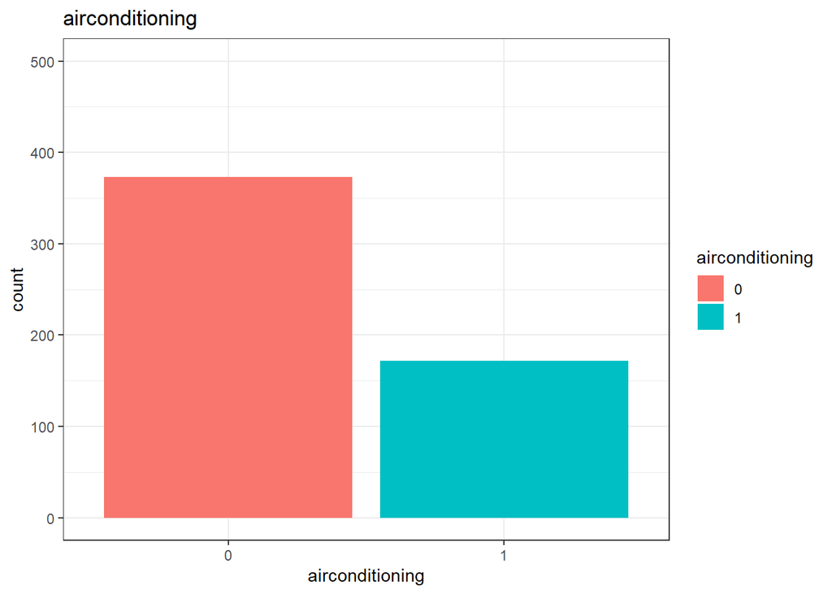

```r
p6 <-  ggplot(housing_data, aes(x=airconditioning, fill=airconditioning)) +
  theme_bw() +
  geom_bar() +
  ylim(0, 500) +
  labs(title = "airconditioning") +
  scale_x_discrete()
p6
```

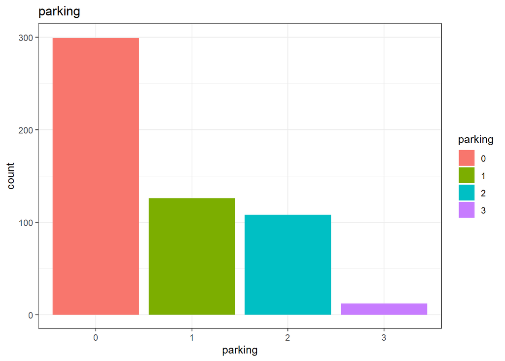

```r
p7 <-  ggplot(housing_data, aes(x=parking, fill=parking)) +
  theme_bw() +
  geom_bar() +
  ylim(0, 300) +
  labs(title = "parking") +
  scale_x_discrete()
p7
```

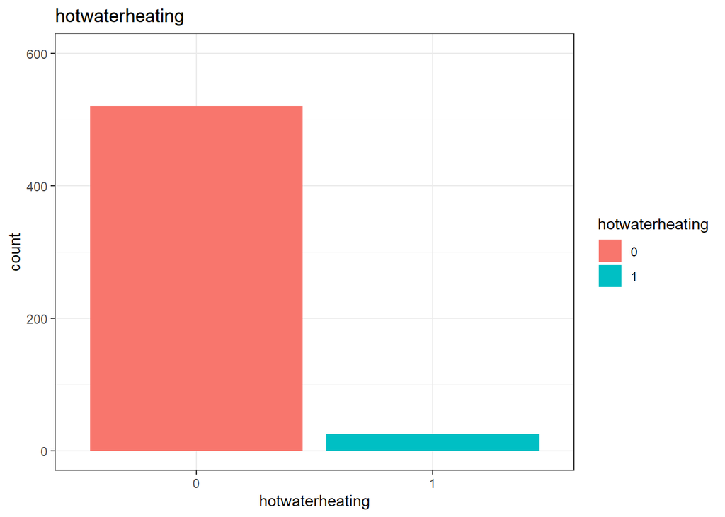

```r
p8 <-  ggplot(housing_data, aes(x=hotwaterheating, fill=hotwaterheating)) +
  theme_bw() +
  geom_bar() +
  ylim(0, 600) +
  labs(title = "hotwaterheating") +
  scale_x_discrete()
p8
```

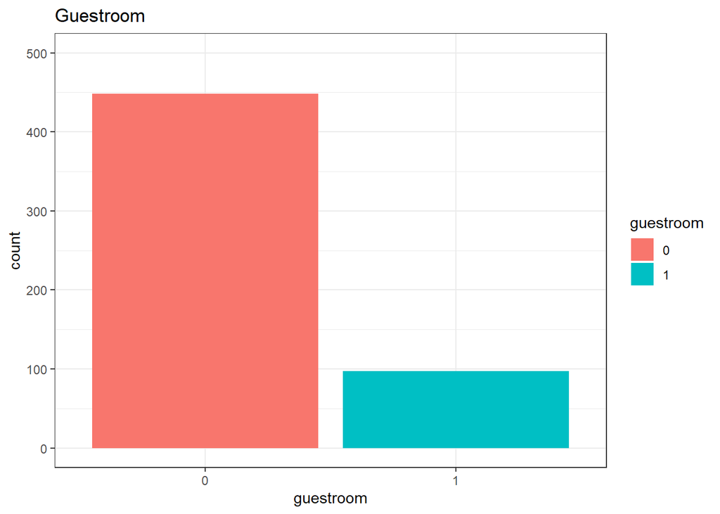

```r
p9 <-  ggplot(housing_data, aes(x=guestroom, fill=guestroom)) +
  theme_bw() +
  geom_bar() +
  ylim(0, 500) +
  labs(title = "Guestroom") +
  scale_x_discrete()
p9
```

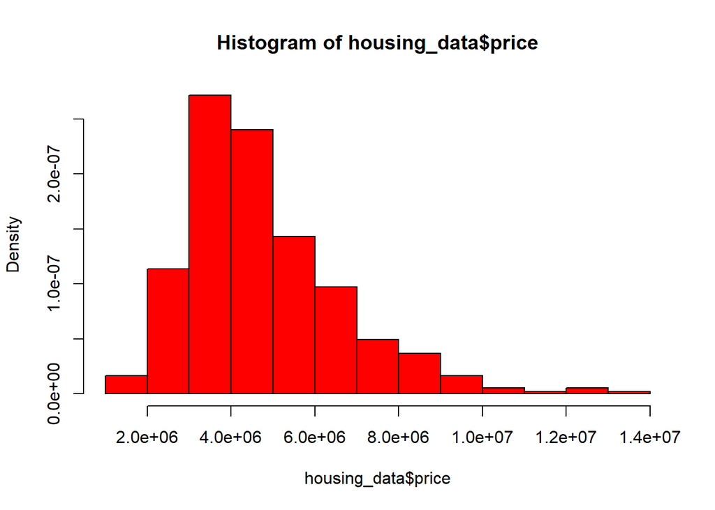

```r
hist(housing_data$price, freq=FALSE,col = "red")
```

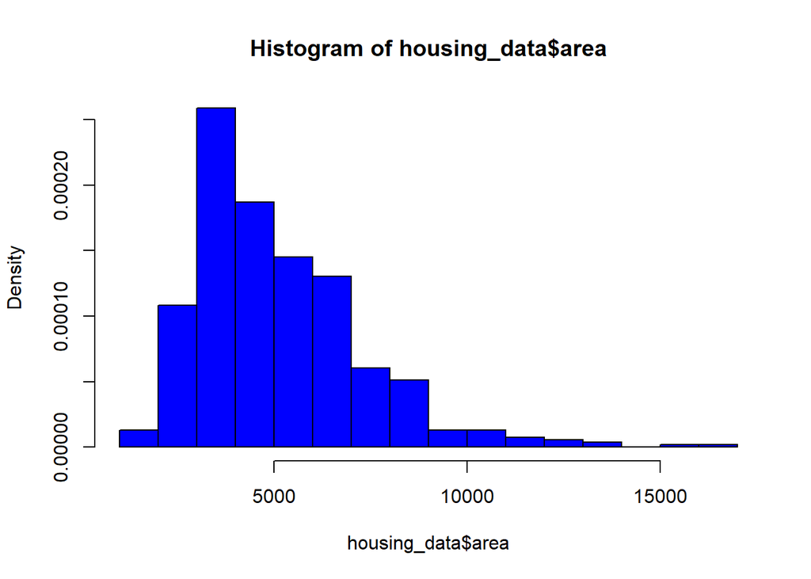

```r
hist(housing_data$area,freq=FALSE, col = "blue")
```

**Correlation**

```r
cov_matrix<-cov(orig_data)
cov_matrix
```

```
##                         price          area      bedrooms    bathrooms
## price            3.498544e+12  2.175676e+09  5.059464e+05 4.864093e+05
## area             2.175676e+09  4.709512e+06  2.432321e+02 2.113466e+02
## bedrooms         5.059464e+05  2.432321e+02  5.447383e-01 1.386738e-01
## bathrooms        4.864093e+05  2.113466e+02  1.386738e-01 2.524757e-01
## furnishingstatus 2.169772e+05  1.416384e+02  3.462797e-02 2.746054e-02
## stories          6.826446e+05  1.581294e+02  2.615893e-01 1.421715e-01
## mainroad         1.936075e+05  2.185582e+02 -3.096330e-03 7.427145e-03
## guestroom        1.829747e+05  1.165634e+02  2.276039e-02 2.432879e-02
## basement         1.670850e+05  4.914084e+01  3.429911e-02 2.450081e-02
## hotwaterheating  3.645362e+04 -4.193993e+00  7.116838e-03 7.066244e-03
## airconditioning  3.941112e+05  2.245072e+02  5.514031e-02 4.368929e-02
## parking          6.194673e+05  6.599897e+02  8.856247e-02 7.684161e-02
## prefarea         2.617215e+05  2.161833e+02  2.474703e-02 1.353211e-02
##                  furnishingstatus       stories      mainroad     guestroom
## price                2.169772e+05  6.826446e+05  1.936075e+05  1.829747e+05
## area                 1.416384e+02  1.581294e+02  2.185582e+02  1.165634e+02
## bedrooms             3.462797e-02  2.615893e-01 -3.096330e-03  2.276039e-02
## bathrooms            2.746054e-02  1.421715e-01  7.427145e-03  2.432879e-02
## furnishingstatus     1.449221e-01  3.456726e-02  2.080073e-02  1.724568e-02
## stories              3.456726e-02  7.525432e-01  3.680855e-02  1.445966e-02
## mainroad             2.080073e-02  3.680855e-02  1.215461e-01  1.232461e-02
## guestroom            1.724568e-02  1.445966e-02  1.232461e-02  1.465731e-01
## basement             2.051234e-02 -7.141797e-02  7.325958e-03  6.802482e-02
## hotwaterheating      2.521249e-03  3.423502e-03 -8.600917e-04 -8.263627e-04
## airconditioning      2.664767e-02  1.184802e-01  1.709727e-02  2.460874e-02
## parking              5.823158e-02  3.404277e-02  6.140718e-02  1.235834e-02
## prefarea             1.739409e-02  1.635186e-02  2.956692e-02  2.613667e-02
##                       basement hotwaterheating airconditioning      parking
## price             1.670850e+05    3.645362e+04    3.941112e+05 6.194673e+05
## area              4.914084e+01   -4.193993e+00    2.245072e+02 6.599897e+02
## bedrooms          3.429911e-02    7.116838e-03    5.514031e-02 8.856247e-02
## bathrooms         2.450081e-02    7.066244e-03    4.368929e-02 7.684161e-02
## furnishingstatus  2.051234e-02    2.521249e-03    2.664767e-02 5.823158e-02
## stories          -7.141797e-02    3.423502e-03    1.184802e-01 3.404277e-02
## mainroad          7.325958e-03   -8.600917e-04    1.709727e-02 6.140718e-02
## guestroom         6.802482e-02   -8.263627e-04    2.460874e-02 1.235834e-02
## basement          2.280559e-01    4.384781e-04    1.051673e-02 2.118861e-02
## hotwaterheating   4.384781e-04    4.384781e-02   -1.266527e-02 1.224366e-02
## airconditioning   1.051673e-02   -1.266527e-02    2.163923e-01 6.379520e-02
## parking           2.118861e-02    1.224366e-02    6.379520e-02 7.423300e-01
## prefarea          4.621560e-02   -5.278602e-03    2.316851e-02 3.349636e-02
##                       prefarea
## price             2.617215e+05
## area              2.161833e+02
## bedrooms          2.474703e-02
## bathrooms         1.353211e-02
## furnishingstatus  1.739409e-02
## stories           1.635186e-02
## mainroad          2.956692e-02
## guestroom         2.613667e-02
## basement          4.621560e-02
## hotwaterheating  -5.278602e-03
## airconditioning   2.316851e-02
## parking           3.349636e-02
## prefarea          1.800324e-01
```

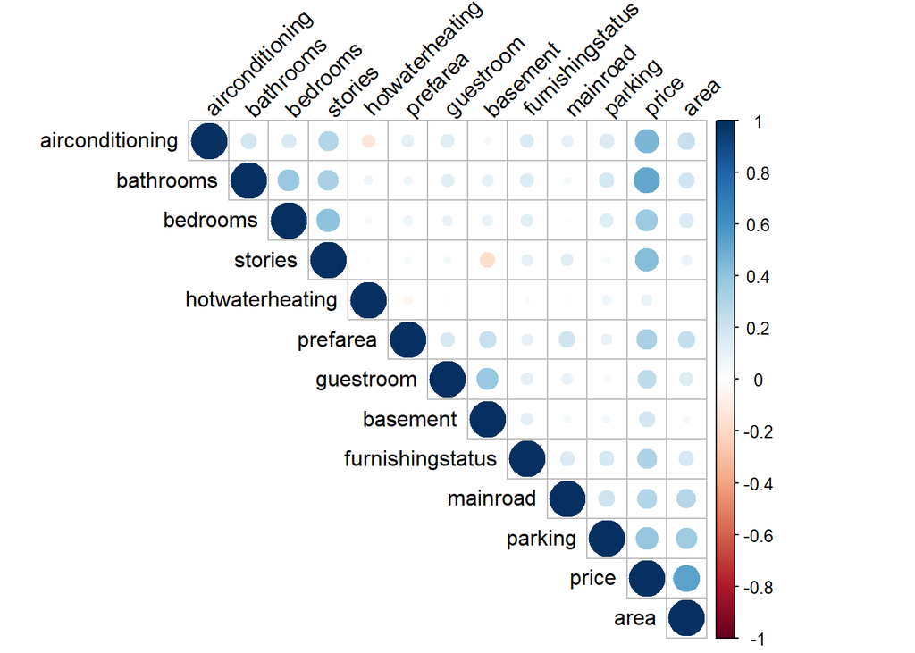

```r
cor_matrix<-cor(orig_data)

corrplot(cor_matrix, type = "upper", order = "hclust",
         tl.col = "black", tl.srt = 45)
```

As we can see that in above cor_matrix that the price has a correlation with all the other variables.

```r
cor_matrix[,'price']
```

```
##            price             area         bedrooms        bathrooms
##       1.00000000       0.53599735       0.36649403       0.51754534
## furnishingstatus          stories         mainroad        guestroom
##       0.30472146       0.42071237       0.29689849       0.25551729
##         basement  hotwaterheating  airconditioning          parking
##       0.18705660       0.09307284       0.45295408       0.38439365
##         prefarea
##       0.32977705
```

## **Regression Analysis (Price)**

we will perform regression analysis on variable area to solve our first problem statement.

1. In my opinion, the price increased when the area of house increase.
2. Other variables affecting the prices of house? eg. bedrooms, bathrooms, etc.

**Price ~ Area**

```r
price_Area = lm(housing_data$price~housing_data$area)
summary(price_Area)
```

```
##
## Call:
## lm(formula = housing_data$price ~ housing_data$area)
##
## Residuals:
##      Min       1Q   Median       3Q      Max
## -4867112 -1022228  -200135   683027  7484838
##
## Coefficients:
##                    Estimate Std. Error t value Pr(>|t|)
## (Intercept)       2.387e+06  1.745e+05   13.68   <2e-16 ***
## housing_data$area 4.620e+02  3.123e+01   14.79   <2e-16 ***
## ---
## Signif. codes:  0 '***' 0.001 '**' 0.01 '*' 0.05 '.' 0.1 ' ' 1
##
## Residual standard error: 1581000 on 543 degrees of freedom
## Multiple R-squared:  0.2873, Adjusted R-squared:  0.286
## F-statistic: 218.9 on 1 and 543 DF,  p-value: < 2.2e-16
```

```r
coef(price_Area)
```

```
##       (Intercept) housing_data$area
##      2387308.4824          461.9749
```

```r
confint(price_Area)
```

```
##                          2.5 %       97.5 %
## (Intercept)       2044535.0595 2730081.9053
## housing_data$area     400.6371     523.3127
```

```r
price_Area$coefficients
```

```
##       (Intercept) housing_data$area
##      2387308.4824          461.9749
```

{Price} = a + {Area} * b

You can see the values of the intercept “a” and the slope “b” for the area. These “a” and “b” values plot a line between all the points of the data. So in this case, if there is a house with 7777 area, a is 2387308.4824 and b is 461.9749, the model predicts (on average) that its price is around 2387308.4824+ (461.9749* 7777) = 5,980,087.2797.

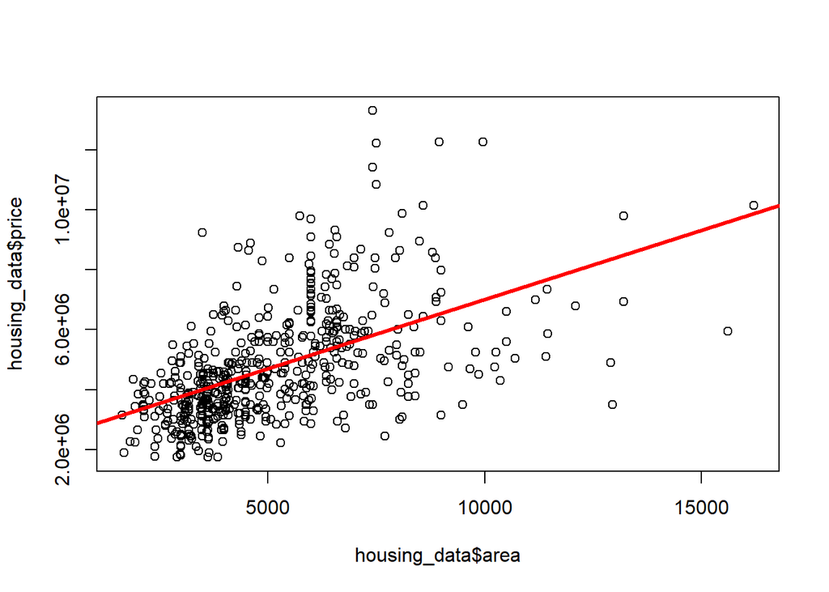

```r
plot(housing_data$area,housing_data$price)
abline(price_Area,col="red",lwd=3)
```

```r
all_variable = lm(orig_data$price~.,data=orig_data)
summary(all_variable)
```

```
##
## Call:
## lm(formula = orig_data$price ~ ., data = orig_data)
##
## Residuals:
##      Min       1Q   Median       3Q      Max
## -2657636  -642433   -47099   508148  5098135
##
## Coefficients:
##                    Estimate Std. Error t value Pr(>|t|)
## (Intercept)      -324509.05  236816.49  -1.370 0.171172
## area                 243.91      24.33  10.024  < 2e-16 ***
## bedrooms          119474.39   72675.18   1.644 0.100777
## bathrooms         988888.29  103543.07   9.551  < 2e-16 ***
## furnishingstatus  426375.56  126119.67   3.381 0.000776 ***
## stories           450391.52   64282.34   7.006 7.42e-12 ***
## mainroad          423100.74  142472.67   2.970 0.003115 **
## guestroom         298030.51  131935.97   2.259 0.024293 *
## basement          357926.36  110383.85   3.243 0.001259 **
## hotwaterheating   872936.03  223311.48   3.909 0.000105 ***
## airconditioning   853633.59  108341.74   7.879 1.87e-14 ***
## parking           279785.64   58608.60   4.774 2.34e-06 ***
## prefarea          647055.60  115857.64   5.585 3.73e-08 ***
## ---
## Signif. codes:  0 '***' 0.001 '**' 0.01 '*' 0.05 '.' 0.1 ' ' 1
##
## Residual standard error: 1070000 on 532 degrees of freedom
## Multiple R-squared:  0.6801, Adjusted R-squared:  0.6729
## F-statistic: 94.24 on 12 and 532 DF,  p-value: < 2.2e-16
```

Lets check the impact of variables other than price.

Replacing values of column **furnishingstatus**:

1 -> Furnished

0.5 -> Semi-Furnished

0 -> Unfurnished

```r
plot_data <- orig_data
```

Lets see some visual representation of other variable with respect to boxplot and see are they affecting the price?

**Single variable box plot with price.**

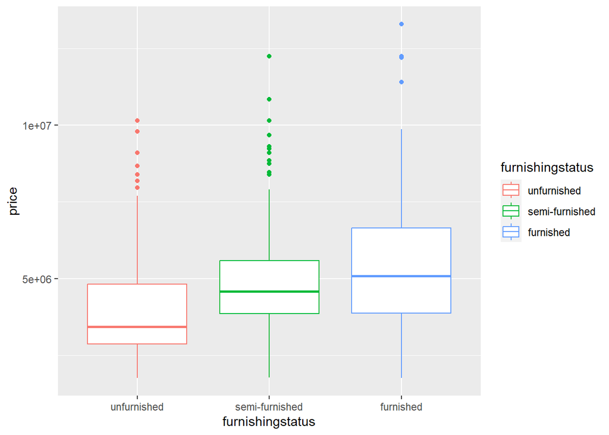

```r
#furnishingstatus
ggplot(housing_data, aes(x=furnishingstatus, y=price,color=furnishingstatus)) +
  geom_boxplot()
```

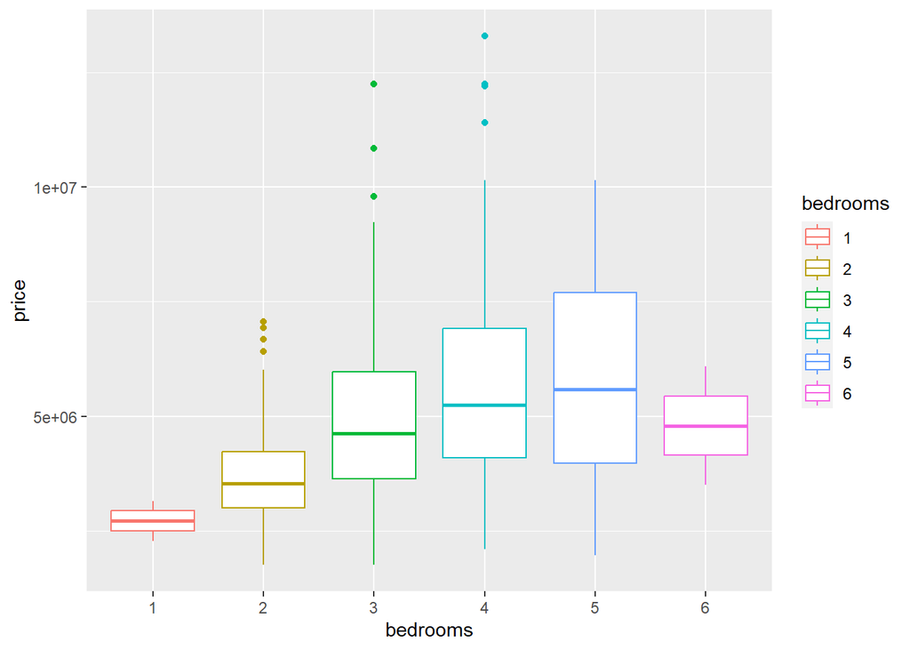

```r
#bedrooms
ggplot(housing_data, aes(x=bedrooms, y=price,color=bedrooms)) +
  geom_boxplot()
```

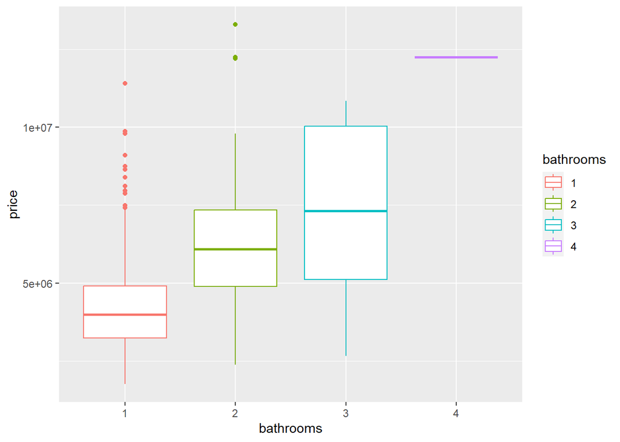

```r
#bathrooms
ggplot(housing_data, aes(x=bathrooms, y=price,color=bathrooms)) +
  geom_boxplot()
```

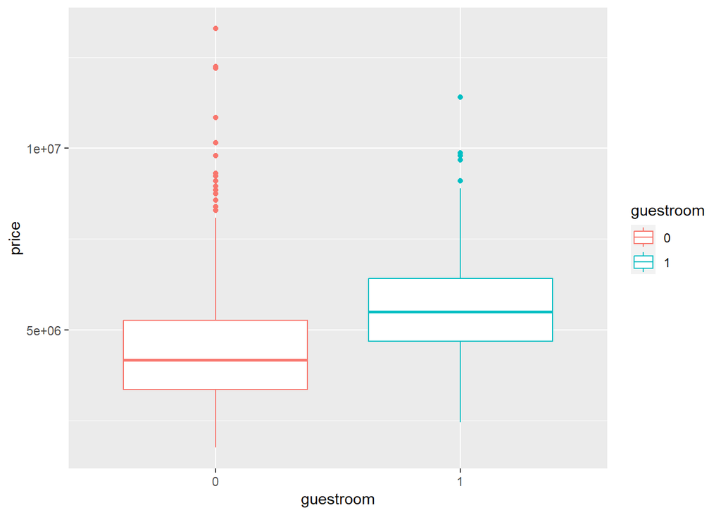

```r
#bathrooms
ggplot(housing_data, aes(x=guestroom, y=price,color=guestroom)) +
  geom_boxplot()
```

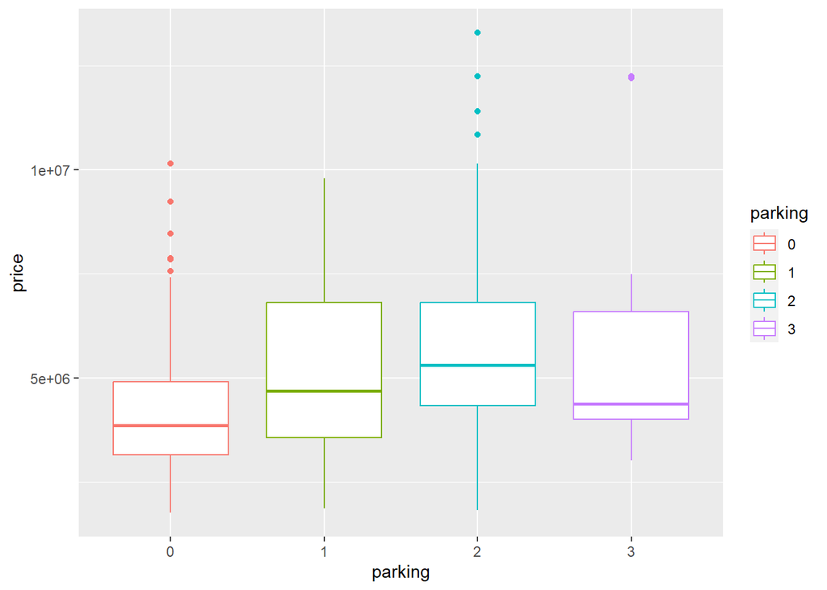

```r
#parking
ggplot(housing_data, aes(x=parking, y=price,color=parking)) +
  geom_boxplot()
```

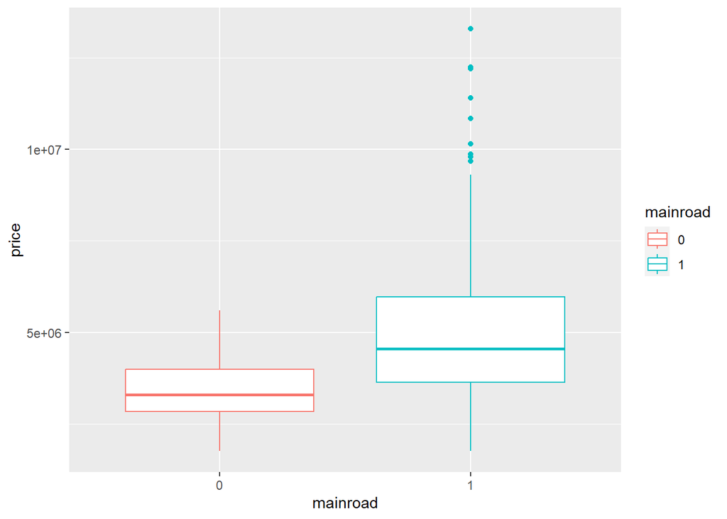

```r
#mainroad
ggplot(housing_data, aes(x=mainroad, y=price,color=mainroad)) +
  geom_boxplot()
```

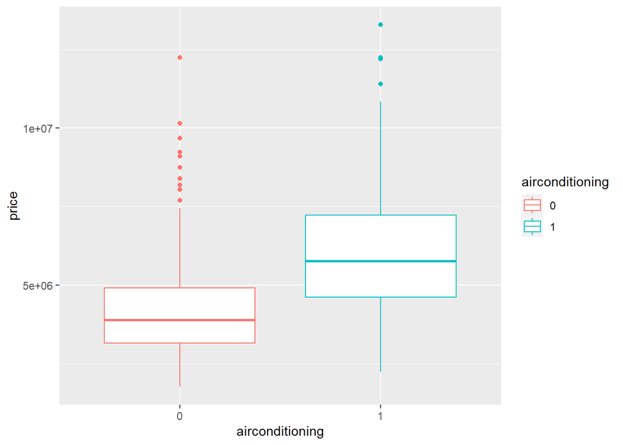

```r
#airconditioning
ggplot(housing_data, aes(x=airconditioning, y=price,color=airconditioning)) +
  geom_boxplot()
```

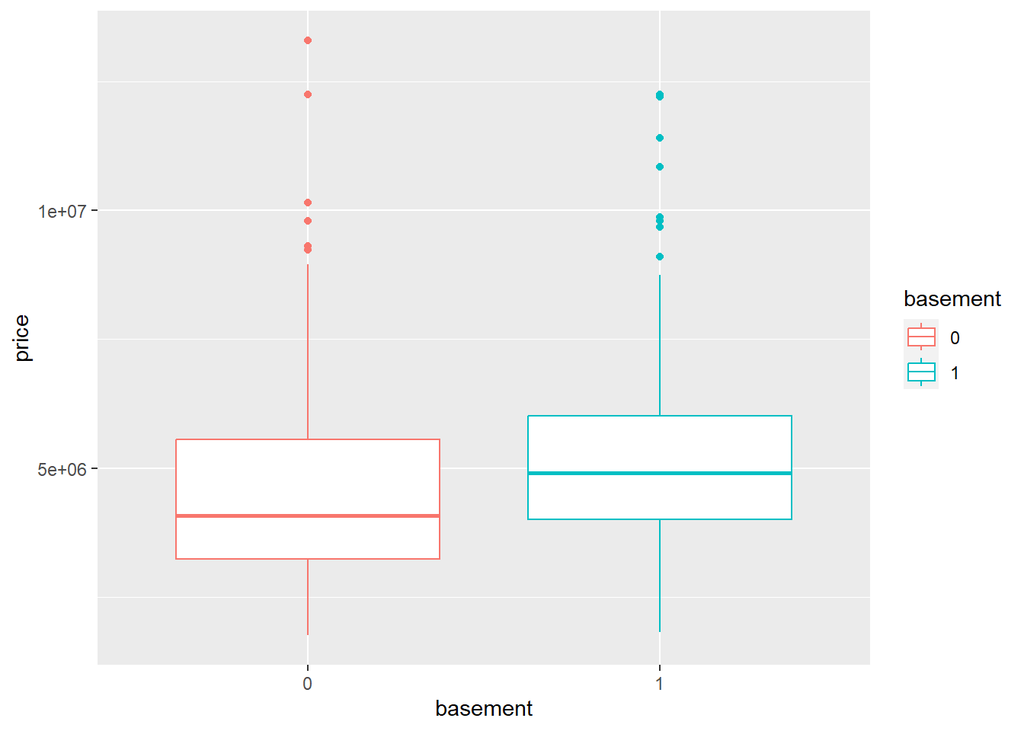

```r
#basement
ggplot(housing_data, aes(x=basement, y=price,color=basement)) +
  geom_boxplot()
```

**Grouped box plotting**

**Price vs [Furnishing status , Airconditioning]**

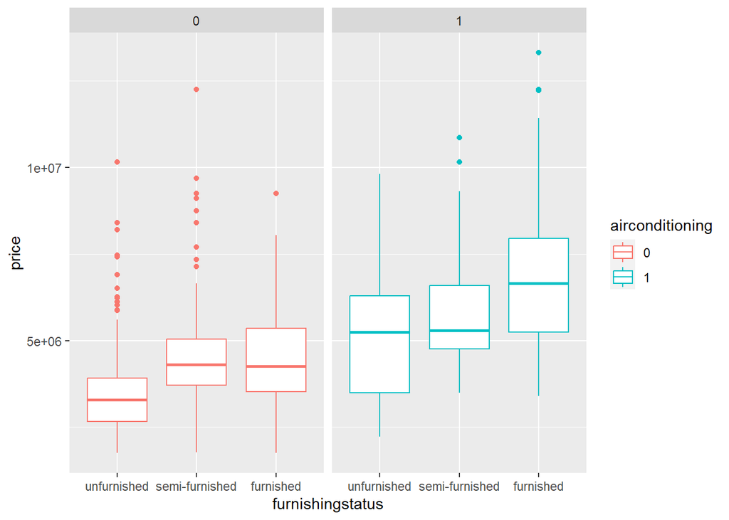

```r
ggplot(housing_data, aes(x=furnishingstatus, y=price , color = airconditioning)) +
  geom_boxplot() + facet_wrap(~airconditioning)
```

**Price vs [Furnishing status , guestroom]**

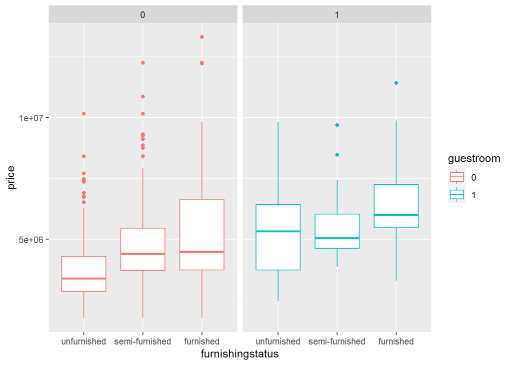

```r
ggplot(housing_data, aes(x=furnishingstatus, y=price , color = guestroom)) +
  geom_boxplot() + facet_wrap(~guestroom)
```

**Price vs [Area , Mainroad]**

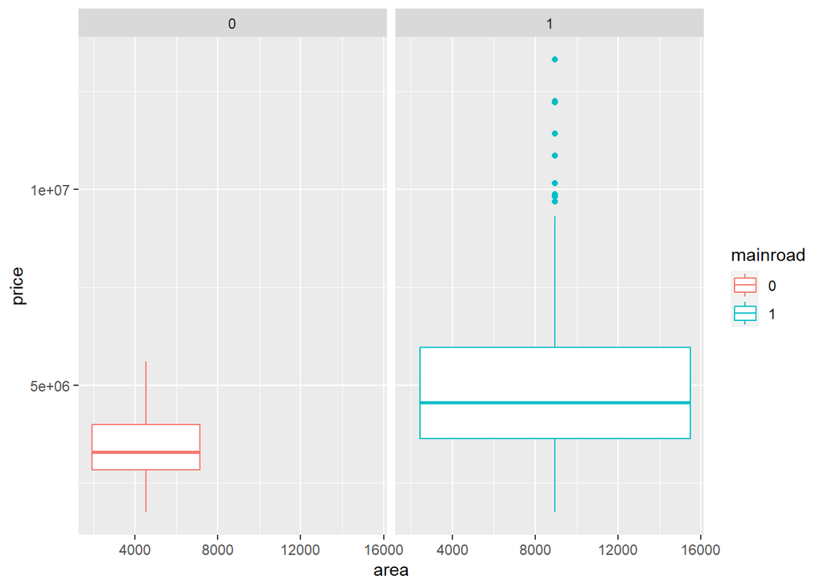

```r
ggplot(housing_data, aes(x=area, y=price , color = mainroad)) +
  geom_boxplot() + facet_wrap(~mainroad)
```

**Price vs [Area, Basement]**

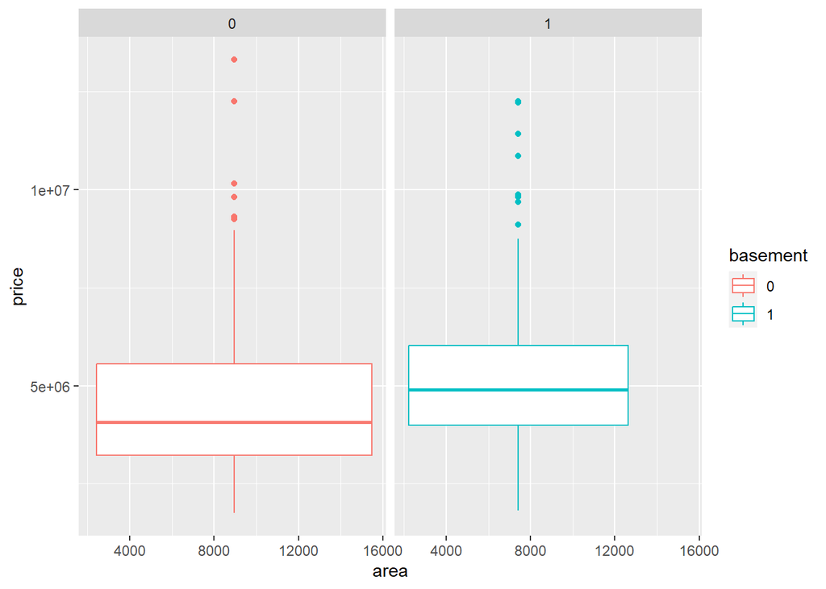

```r
ggplot(housing_data, aes(x=area, y=price , color = basement)) +
  geom_boxplot() + facet_wrap(~basement)
```

**Price vs [Furnishing Status, Hot Water Heating]**

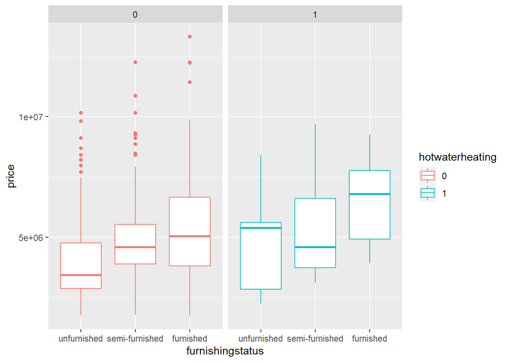

```r
ggplot(housing_data, aes(x=furnishingstatus, y=price , color = hotwaterheating)) +
  geom_boxplot() + facet_wrap(~hotwaterheating)
```

```r
all_impact_variable = lm(orig_data$price~orig_data$area+orig_data$bathrooms+orig_data$stories+orig_data$hotwaterheating+orig_data$airconditioning+orig_data$parking+orig_data$prefarea+orig_data$furnishingstatus)
summary(all_impact_variable)
```

```
##
## Call:
## lm(formula = orig_data$price ~ orig_data$area + orig_data$bathrooms +
##     orig_data$stories + orig_data$hotwaterheating + orig_data$airconditioning +
##     orig_data$parking + orig_data$prefarea + orig_data$furnishingstatus)
##
## Residuals:
##      Min       1Q   Median       3Q      Max
## -2925615  -695667   -85657   555426  5219217
##
## Coefficients:
##                             Estimate Std. Error t value Pr(>|t|)
## (Intercept)                2.523e+05  1.736e+05   1.453  0.14678
## orig_data$area             2.606e+02  2.439e+01  10.687  < 2e-16 ***
## orig_data$bathrooms        1.084e+06  1.025e+05  10.575  < 2e-16 ***
## orig_data$stories          4.464e+05  5.969e+04   7.478 3.11e-13 ***
## orig_data$hotwaterheating  8.911e+05  2.300e+05   3.874  0.00012 ***
## orig_data$airconditioning  8.981e+05  1.111e+05   8.084 4.20e-15 ***
## orig_data$parking          2.995e+05  5.979e+04   5.008 7.46e-07 ***
## orig_data$prefarea         8.223e+05  1.153e+05   7.134 3.18e-12 ***
## orig_data$furnishingstatus 5.310e+05  1.287e+05   4.126 4.28e-05 ***
## ---
## Signif. codes:  0 '***' 0.001 '**' 0.01 '*' 0.05 '.' 0.1 ' ' 1
##
## Residual standard error: 1102000 on 536 degrees of freedom
## Multiple R-squared:  0.6578, Adjusted R-squared:  0.6527
## F-statistic: 128.8 on 8 and 536 DF,  p-value: < 2.2e-16
```

**Price = *a + {area}b1 + {bathrooms}b2 + {stories}b3 + {hotwaterheating}*b4 + {airconditioning}*b5 + {parking}*b6 + {prefarea}*b7 + {furnishingstatud}*b8***

```r
Factor_variable = lm(housing_data$price~.,data=housing_data)
summary(Factor_variable)
```

```
##
## Call:
## lm(formula = housing_data$price ~ ., data = housing_data)
##
## Residuals:
##      Min       1Q   Median       3Q      Max
## -2798873  -663461   -59293   509704  5249000
##
## Coefficients:
##                                  Estimate Std. Error t value Pr(>|t|)
## (Intercept)                    1412837.46  762548.77   1.853 0.064479 .
## area                               235.62      24.96   9.442  < 2e-16 ***
## bedrooms2                      -121224.21  763298.00  -0.159 0.873875
## bedrooms3                       119897.61  766050.81   0.157 0.875689
## bedrooms4                       204453.78  776535.34   0.263 0.792431
## bedrooms5                       352331.32  843096.88   0.418 0.676191
## bedrooms6                       861907.29 1076888.59   0.800 0.423862
## bathrooms2                      889309.60  121853.03   7.298 1.10e-12 ***
## bathrooms3                     2087419.84  357299.19   5.842 9.08e-09 ***
## bathrooms4                     5309187.73 1132696.27   4.687 3.54e-06 ***
## furnishingstatussemi-furnished  389305.21  110318.48   3.529 0.000454 ***
## furnishingstatusfurnished       417022.33  127026.27   3.283 0.001096 **
## stories2                        300434.37  121020.21   2.483 0.013360 *
## stories3                        832268.81  208078.72   4.000 7.26e-05 ***
## stories4                       1406036.05  216192.56   6.504 1.84e-10 ***
## mainroad1                       433968.54  143672.89   3.021 0.002647 **
## guestroom1                      284657.48  132188.26   2.153 0.031743 *
## basement1                       373520.17  112121.12   3.331 0.000925 ***
## hotwaterheating1                839134.50  226392.66   3.707 0.000233 ***
## airconditioning1                843080.22  109913.76   7.670 8.48e-14 ***
## parking1                        396938.75  119101.07   3.333 0.000921 ***
## parking2                        622112.73  130978.04   4.750 2.64e-06 ***
## parking3                        112217.86  336032.76   0.334 0.738552
## prefarea                        647611.82  118363.86   5.471 6.95e-08 ***
## ---
## Signif. codes:  0 '***' 0.001 '**' 0.01 '*' 0.05 '.' 0.1 ' ' 1
##
## Residual standard error: 1066000 on 521 degrees of freedom
## Multiple R-squared:  0.6889, Adjusted R-squared:  0.6752
## F-statistic: 50.17 on 23 and 521 DF,  p-value: < 2.2e-16
```

**Scattered Plot**

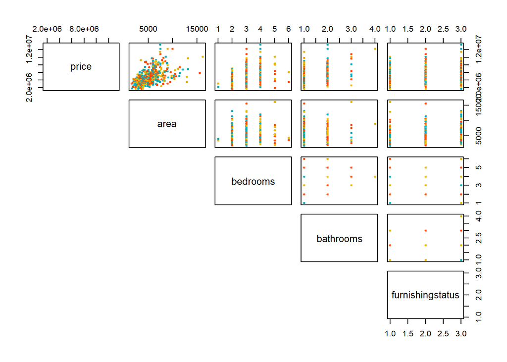

```r
my_cols <- c("#00AFBB", "#E7B800", "#FC4E07")
pairs(housing_data[,1:5], pch = 19,cex = 0.5,
      col = my_cols,lower.panel = NULL)
```